# IGNITE Zagreb workshop: Introduction to Statistics

Maja Kuzman

2019-08-30

## Introduction

This chapter introduces the statistical concepts necessary to understand p-values and confidence intervals. These terms are ubiquitous in the life science literature. Let’s use [this paper](http://diabetes.diabetesjournals.org/content/53/suppl_3/S215.full) as an example.

Imagine that we actually have the weight of the entire population of mice and can upload them to R. In Statistics, we refer to this as *the population*. Note that in practice we do not have access to the population. We have a special dataset that we are using here to illustrate concepts.

| Sex | Diet | Bodyweight |
| --- | --- | --- |
| F | hf | 31.940 |
| F | hf | 32.480 |
| F | hf | 22.820 |
| F | hf | 19.920 |
| F | hf | 32.220 |
| F | hf | 27.500 |
| F | hf | 27.560 |
| F | hf | 36.440 |
| F | hf | 19.390 |
| F | hf | 23.160 |

[output cut: 836 more lines]

#### Our first look at data

```r
SampleThePopulation <- function(n, seed=1.23, onlyfemale=T, nullhyp = FALSE){
    if (seed!=1.23) set.seed(seed)
    pop <- copy(population)
    if(nullhyp==TRUE) {
        n=n*2
        pop <- pop[Diet=="chow"]
        pop[sample(1:nrow(pop),nrow(pop)/2),Diet:="chow2"]
        }
    if(onlyfemale==F){
        mice <- pop[,.SD[sample(1:.N,round(n/4))],.(Sex,Diet)]
    }

    if(onlyfemale==T){
        mice <- pop[Sex=="F",.SD[sample(1:.N,round(n/2))],.(Diet)]
    }
    mice
}
```

We are interested in determining if following a given diet makes mice heavier after several weeks. This data was produced by ordering 24 mice from The Jackson Lab and randomly assigning either chow or high fat (hf) diet. The function SampleThePopulation simulates the experiment for us. It takes the number of mice you wish to order from the Jackson Lab and randomly assigns half of them to control (chow) diet and half of them to hihgh fat (hf) diet and returns the bodyweight of mice after several weeks. (By default it will only give you the female mice, since this might influence the results.)

Note: To make sure that we all work with the same sample, we use “seed”. By changing the seed to any number you get a different sample. Same seed and the same size will always give the same subsample from the population.

After several weeks, the scientists weighed each mouse and obtained this data:

```r
oneExperiment <- SampleThePopulation(24,seed = 1)
oneExperiment
```

| Diet | Sex | Bodyweight |
| --- | --- | --- |
| hf | F | 25.37 |
| hf | F | 30.11 |
| hf | F | 22.57 |
| hf | F | 18.35 |
| hf | F | 31.15 |
| hf | F | 24.30 |
| hf | F | 39.42 |
| hf | F | 26.46 |
| hf | F | 36.23 |
| hf | F | 29.18 |

[output cut: 14 more lines]

```r
NA
```

In RStudio, you can view the entire dataset with:

```r
View(oneExperiment)
```

So are the hf mice heavier? Mouse 4 at 18.35 grams is one of the lightest mice, while Mouse 7 at 39.42 grams is one of the heaviest from the female mice. Both are on the hf diet. Just from looking at the data, we see there is *variability*.

One way to compare two groups is to plot all the values in one group in a histogram and all the values from the other group as well in the same plot. In R, this is done easily like this:

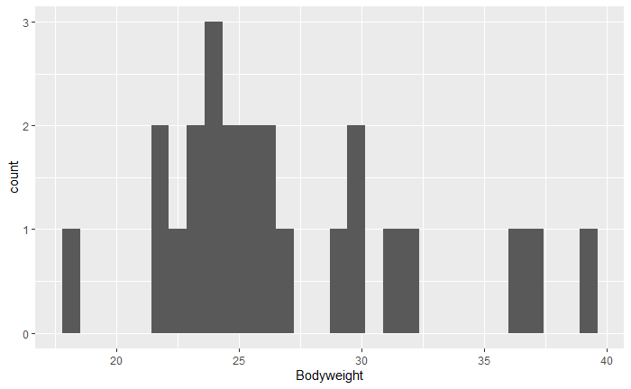

```r
library(ggplot2)

ggplot(oneExperiment, aes(Bodyweight)) +
    geom_histogram()
```

If you want to see the result by groups you can add fill= and the name of the variable you wish to group by. So lets do it by Diet variable:

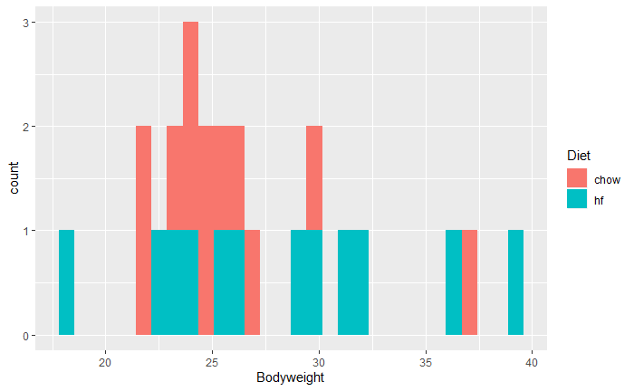

```r
ggplot(oneExperiment, aes(Bodyweight, fill=Diet)) +
    geom_histogram()
```

Another way to see this is to use a density plot. Do this by copy pasting the previous code and changing geom_histogram() to geom_density(). If you want to make the plot transparent add alpha=0.5 inside the geom_density brackets.

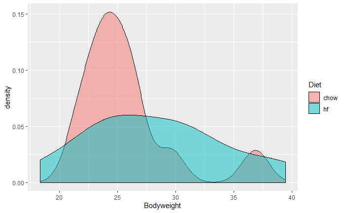

```r
ggplot(oneExperiment, aes(Bodyweight, fill=Diet)) +
    geom_density(alpha=0.5)
```

Can you based on this conclude if the weights are different for two groups?

Other common representation of such data is to use a boxplot. Note that now we need to provide a variable for x axis (Diet) and for the y axis (Bodyweight). Would you say that the groups have different weights based on this?

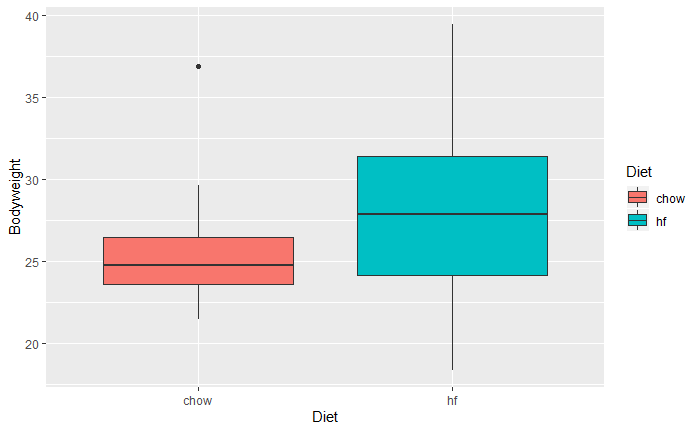

```r
ggplot(oneExperiment, aes(Diet, Bodyweight, fill=Diet)) +
    geom_boxplot()
```

```r
NA
```

It is not easy to decide if two variables have the same distribution. This is why we usually refer to the averages. So let’s look at the average of each group:

```r
control <- oneExperiment[Diet=="chow", Bodyweight]
treatment <- oneExperiment[Diet=="hf", Bodyweight]
print( mean(treatment) )
```

```
[1] 28.215
```

```r
print( mean(control) )
```

```
[1] 25.7275
```

Are high fat diet mice heavier on average then the control group? How much? Compare those values!

```r
mean(treatment)/mean(control)
```

```
[1] 1.096686
```

```r
obsdiff <- mean(treatment)-mean(control)
obsdiff
```

```
[1] 2.4875
```

So the hf diet mice are about 10% heavier. Are we done? Why do we need p-values and confidence intervals?

The reason is that these averages are random variables. They can take many values. What does this mean? If we repeat the experiment, we obtain 24 new mice from The Jackson Laboratory and, after randomly assigning them to each diet, we get a different mean.

Try this yourself!

1. Order a new sample form Jackson lab of 24 female mice. Set seed to 18 so we get a different sample then previous time. To do this, replace the values ??? with proper values:

```r
Experiment2 <- SampleThePopulation(n= 24, seed = 18)
```

2. Divide the dataset into control2 and treatment2 variables which contain the weights for the mice in this experiment.

```r
#treatment2 <- ???
#control2 <- ???
```

3. Calculate and compare the means of the groups now. How different are the weights now? What does this mean?

Every time we repeat this experiment, we get a different value. We call this type of quantity a *random variable*.

For convenience, I made a function which will give us the observed difference between the group means:

```r
getObsDiff <- function(n,seed=1.25, nullhyp=FALSE){
    oneExperiment <- SampleThePopulation(n = n, seed = seed, nullhyp = nullhyp)
    control <- oneExperiment[Diet=="chow", Bodyweight]
    if(nullhyp){
        treatment <- oneExperiment[Diet=="chow2", Bodyweight]
    }else {
        treatment <- oneExperiment[Diet=="hf", Bodyweight]
    }
    obsdiff <- mean(treatment) - mean(control)
    obsdiff
}
```

This is how the previous examples look like if we plot them:

Example with seed=1, 18

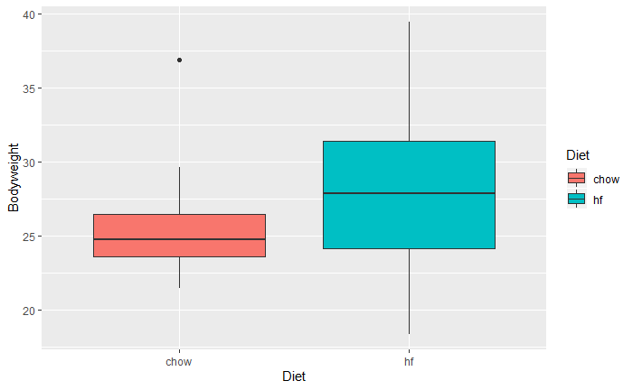

```r
oneExperiment <- SampleThePopulation(n = 24, seed = 1)
ggplot(oneExperiment, aes(Diet, Bodyweight, fill=Diet))+geom_boxplot()
```

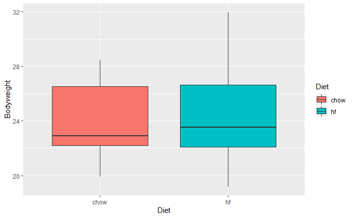

```r
oneExperiment <- SampleThePopulation(n = 24, seed = 18)
ggplot(oneExperiment, aes(Diet, Bodyweight, fill=Diet))+geom_boxplot()
```

and the difference in the means for this samples was:

```r
getObsDiff(24,1)
```

```
[1] 2.4875
```

```r
getObsDiff(24,18)
```

```
[1] 0.5308333
```

Example for random seeds:

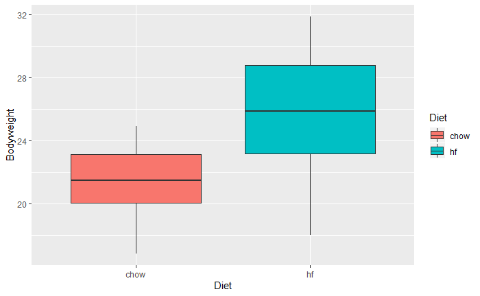

```r
somerandomseed <- sample(1:100000,1)
oneExperiment <- SampleThePopulation(n = 24, seed = somerandomseed)
ggplot(oneExperiment, aes(Diet, Bodyweight, fill=Diet))+geom_boxplot()
```

```r
getObsDiff(24,somerandomseed)
```

```
[1] 4.32
```

Notice two things here:

1. instead of looking at the mean for control and the mean for the treatment group, we can simply look at the difference between them. This is often done in statistics. If the difference between the means is close to 0, this indicates that the two groups are not so different. If the difference between the group means is large, this indicates that the groups can not be so similar. It is important to see that the difference between the groups depends on the sample we take. It changes as we take different samples. So it is a random variable too :).

Now, instead of checking if two groups are different, it is enough to check if the difference between the group means is different from 0. If it is larger then 0 for most of the samples, this means that most of the samples have different means in control and treatment, which indicates that the treatment does effect the bodyweight differently then the control!

2. When we get random samples if the other group is the control group, there would still be difference in means!! In other words, means differ between two control samples.

## Random Variables

Let’s explore random variables further.

Set the seed to different values to see how the average difference between the groups changes. Use seeds 5, 10 and 15. (This numbers are random and you can use any number you wish but the result you get will be different from your collegues if you use different values then them.)

```r
getObsDiff(24,5)
```

```
[1] 0.9433333
```

```r
getObsDiff(24,10)
```

```
[1] 7.355
```

```r
getObsDiff(24,15)
```

```
[1] 1.8925
```

Note how the average difference between the groups varies a lot! We can continue to do this repeatedly and start learning something about the distribution of this random variable!

So can we conclude that it is larger then zero in general (meaning the control and treatment averages are different in general)? Would this difference still appear if we took 2 random samples and didn’t treat them? Would this difference be so large then?

## The Null Hypothesis

Now let’s go back to the second point made earlier! As scientists we need to be skeptics. How do we know that this `obsdiff` is due to the diet? What happens if we give all 24 mice the same diet? Will we see a difference this big? Statisticians refer to this scenario as the *null hypothesis*. The name “null” is used to remind us that we are acting as skeptics: we give credence to the possibility that there is no difference.

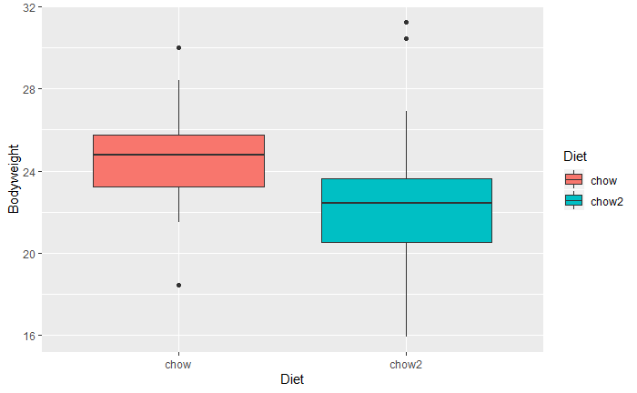

```r
somerandomseed <- sample(1:100000,1)
oneExperiment <- SampleThePopulation(n = 24, seed = somerandomseed, nullhyp = T)
ggplot(oneExperiment, aes(Diet, Bodyweight, fill=Diet))+geom_boxplot()
```

```r
getObsDiff(24,somerandomseed, nullhyp = T)
```

```
[1] -1.93375
```

So the question we are actually interested in is: Is the difference between control and treatment sample larger then difference between different control samples?

Now let’s do it 10,000 times and record the differences between the controls and control.

this takes a long time to run…

```r
controldifference <-  replicate(10000,getObsDiff(24, nullhyp = T))
```

The values in `controldifference` form what we call the *null distribution*. We will define this more formally below.

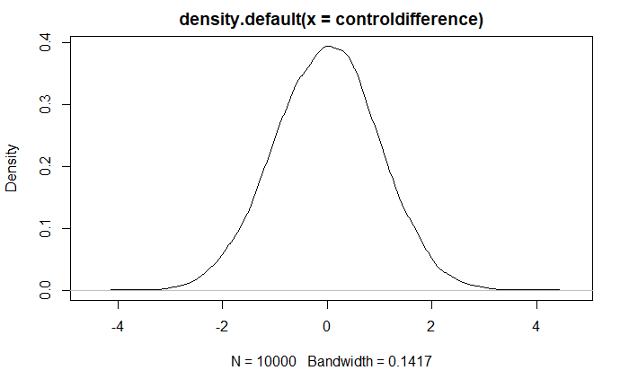

```r
plot(density(controldifference))
```

```r
hist(controldifference, xlim=c(-4,10))
abline(v=getObsDiff(24,1), col=2)
```

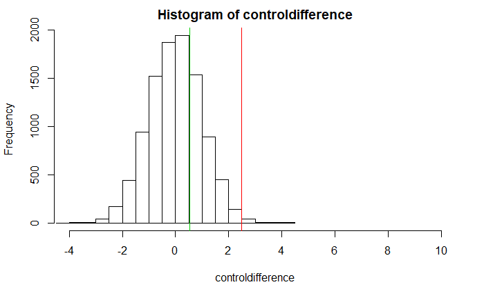

```r
abline(v=getObsDiff(24,18), col=3)
```

In the first example, with seed=1 we got the difference between bontrol and treatment to be 2.4875.

```r
obsdiff <- getObsDiff(24, seed=1)
```

So what percent of the 10,000 are bigger than `obsdiff`?

```r
mean(controldifference >= obsdiff)
```

```
[1] 0.0058
```

```r
mean(abs(controldifference) >= obsdiff)
```

```
[1] 0.0111
```

Now try to take 100 samples from the null distribution and measure the p value!

```r
controldifference100 <- replicate(100,getObsDiff(24, nullhyp = T))

hist(controldifference100, xlim=c(-4,10))
abline(v=getObsDiff(24,1), col=2)
```

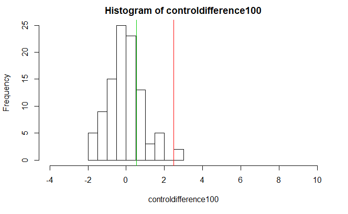

```r
abline(v=getObsDiff(24,18), col=3)
```

```r
mean(abs(controldifference100) >= obsdiff)
```

```
[1] 0.02
```

COOOL! This means we can calculate p values without any tests now!!!

(Well.. yes. If you can take 10000 samples from the population and measure them! … But there IS something cool about this: )